# Comparisons with other packages

2025-04-08

This vignette provides comparisons with other packages that provide similar functionality. This is a work in progress – for a more detailed / complete / coherent comparison with other packages which provide wide-to-tall data reshaping, see [my paper](https://github.com/tdhock/nc-article#paper).

## Are sepals larger or smaller than petals in the iris data?

Sometimes you want to melt a “wide” data table which has several distinct pieces of information encoded in each column name. One example is the familiar iris data, which have flower part and measurement dimension encoded in each of four column names:

```r
library(data.table)
data.table(iris)
```

```
#>      Sepal.Length Sepal.Width Petal.Length Petal.Width   Species
#>             <num>       <num>        <num>       <num>    <fctr>
#>   1:          5.1         3.5          1.4         0.2    setosa
#>   2:          4.9         3.0          1.4         0.2    setosa
#>   3:          4.7         3.2          1.3         0.2    setosa
#>   4:          4.6         3.1          1.5         0.2    setosa
#>   5:          5.0         3.6          1.4         0.2    setosa
#>  ---
#> 146:          6.7         3.0          5.2         2.3 virginica
#> 147:          6.3         2.5          5.0         1.9 virginica
#> 148:          6.5         3.0          5.2         2.0 virginica
#> 149:          6.2         3.4          5.4         2.3 virginica
#> 150:          5.9         3.0          5.1         1.8 virginica
```

The goal in this section will be to convert these data into a format with a column for each flower part (`Sepal` and `Petal`) so we can easily make a facetted scatterplot to visually examine whether or not sepals or larger than petals. The easiest way to perform this conversion is with packages which provide a function for melting into multiple output columns:

```r
iris.parts <- list(
  nc=nc::capture_melt_multiple(
    iris,
    column=".*?",
    "[.]",
    dim=".*"),
  tidyr=if(requireNamespace("tidyr"))tidyr::pivot_longer(
    iris,
    cols=1:4,
    names_to=c(".value", "dim"),
    names_sep="[.]"),
  stats=stats::reshape(
    iris,
    direction="long",
    timevar="dim",
    varying=1:4,
    sep="."),
  "data.table::melt"=melt(
    data.table(iris),
    measure.vars=patterns(
      Sepal="^Sepal",
      Petal="^Petal")
  )[data.table(
    variable=factor(1:2), dim=c("Length", "Width")
  ), on=.(variable)],
  if(requireNamespace("cdata"))cdata::rowrecs_to_blocks(
    iris,
    controlTable=data.frame(
      dim=c("Length", "Width"),
      Petal=c("Petal.Length", "Petal.Width"),
      Sepal=c("Sepal.Length", "Sepal.Width"),
      stringsAsFactors=FALSE),
    columnsToCopy="Species"))
iris.parts$nc
```

```
#>        Species    dim Petal Sepal
#>         <fctr> <char> <num> <num>
#>   1:    setosa Length   1.4   5.1
#>   2:    setosa Length   1.4   4.9
#>   3:    setosa Length   1.3   4.7
#>   4:    setosa Length   1.5   4.6
#>   5:    setosa Length   1.4   5.0
#>  ---
#> 296: virginica  Width   2.3   3.0
#> 297: virginica  Width   1.9   2.5
#> 298: virginica  Width   2.0   3.0
#> 299: virginica  Width   2.3   3.4
#> 300: virginica  Width   1.8   3.0
```

It is clear from the code above that each package is capable of the conversions. However the syntax and level of explicitness varies:

- `nc::capture_melt_multiple` requires a regular expression: (most implicit, least repetition)
  - any input column names that match the regex are melted.
  - values matched in the `column` group are used for the output column names.
- `tidyr::pivot_longer` and `stats::reshape` require specification of the input columns to melt along with a separator.
  - `stats::reshape` assumes the output columns names occur in the part of the input column name before the separator.
  - `tidyr::pivot_longer` assumes the output columns occur in the part which corresponds to the `.value` element of the `names_to` argument.
- `data.table::melt` requires a join to recover the `dim` output column.
- `cdata::rowrecs_to_blocks` requires explicit specification of a control table. (most explicit, most repetition)

Any of the results can be visualized via:

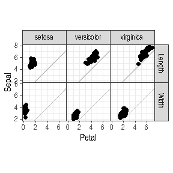

```r
if(require(ggplot2)){
  ggplot()+
    theme_bw()+
    theme(panel.spacing=grid::unit(0, "lines"))+
    facet_grid(dim ~ Species)+
    coord_equal()+
    geom_abline(slope=1, intercept=0, color="grey")+
    geom_point(aes(
      Petal, Sepal),
      data=iris.parts$nc)
}
```

It is clear from the plot above that sepals are larger than petals, for every measured flower.

## Comparing dimensions in iris data

What if we wanted to compare dimensions rather than parts?

```r
iris.dims <- list(
  nc=nc::capture_melt_multiple(
    iris,
    part=".*?",
    "[.]",
    column=".*"),
  stats=stats::reshape(
    structure(iris, names=sub("(.*?)[.](.*)", "\\2.\\1", names(iris))),
    direction="long",
    timevar="part",
    varying=1:4,
    sep="."))
iris.dims$nc
```

```
#>        Species   part Length Width
#>         <fctr> <char>  <num> <num>
#>   1:    setosa  Petal    1.4   0.2
#>   2:    setosa  Petal    1.4   0.2
#>   3:    setosa  Petal    1.3   0.2
#>   4:    setosa  Petal    1.5   0.2
#>   5:    setosa  Petal    1.4   0.2
#>  ---
#> 296: virginica  Sepal    6.7   3.0
#> 297: virginica  Sepal    6.3   2.5
#> 298: virginica  Sepal    6.5   3.0
#> 299: virginica  Sepal    6.2   3.4
#> 300: virginica  Sepal    5.9   3.0
```

The code above shows that the syntax is mostly the same for this example. The biggest difference is for `stats::reshape` which assumes that each input column name is composed of (1) the output column name, (2) a delimiter, and (3) some additional information to be stored in the output column given by `timevar`. Therefore we need to pre-process column names using `sub` for it to work.

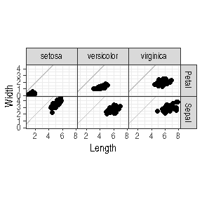

```r
if(require(ggplot2)){
  ggplot()+
    theme_bw()+
    theme(panel.spacing=grid::unit(0, "lines"))+
    facet_grid(part ~ Species)+
    coord_equal()+
    geom_abline(slope=1, intercept=0, color="grey")+
    geom_point(aes(
      Length, Width),
      data=iris.dims$nc)
}
```

It is clear from the plot above that `Length` is larger than `Width` for every measured flower part.

## Do columns need to be sorted?

Consider the following wide data set:

```r
TC <- data.table::data.table(
  age.treatment=c(1, 5),
  sex.control=c("M", "M"),
  sex.treatment=c("F", "F"),
  age.control=c(10, 50))
```

It is clear from the column names how the data should be grouped when they are converted to tall format. However the columns do not appear in regular order (age is before sex for treatment, but age is after sex for control), which causes a problem for stats and data.table:

```r
input.list <- list(
  "nc"=nc::capture_melt_multiple(
    TC,
    column=".*?",
    "[.]",
    group=".*"),
  "cdata"=if(requireNamespace("cdata"))cdata::rowrecs_to_blocks(
    TC,
    controlTable=data.frame(
      group=c("treatment", "control"),
      age=c("age.treatment", "age.control"),
      sex=c("sex.treatment", "sex.control"),
      stringsAsFactors=FALSE)),
  "data.table"=data.table::melt(TC, measure.vars=patterns(
    age="age",
    sex="sex")),
  "stats"=stats::reshape(
    TC,
    varying=1:4,
    direction="long"),
  "tidyr"=if(requireNamespace("tidyr"))tidyr::pivot_longer(
    TC, 1:4,
    names_to=c(".value", "group"),
    names_sep="[.]"))
output.list <- list()
for(pkg in names(input.list)){
  df.or.null <- input.list[[pkg]]
  if(is.data.frame(df.or.null)){
    output.list[[pkg]] <- data.table::data.table(df.or.null)[order(age)]
  }
}
output.list
```

```
#> $nc
#>        group   age    sex
#>       <char> <num> <char>
#> 1: treatment     1      F
#> 2: treatment     5      F
#> 3:   control    10      M
#> 4:   control    50      M
#>
#> $cdata
#>        group   age    sex
#>       <char> <num> <char>
#> 1: treatment     1      F
#> 2: treatment     5      F
#> 3:   control    10      M
#> 4:   control    50      M
#>
#> $data.table
#>    variable   age    sex
#>      <fctr> <num> <char>
#> 1:        1     1      M
#> 2:        1     5      M
#> 3:        2    10      F
#> 4:        2    50      F
#>
#> $stats
#>         time   age    sex    id
#>       <char> <num> <char> <int>
#> 1: treatment     1      M     1
#> 2: treatment     5      M     2
#> 3:   control    10      F     1
#> 4:   control    50      F     2
#>
#> $tidyr
#>        group   age    sex
#>       <char> <num> <char>
#> 1: treatment     1      F
#> 2: treatment     5      F
#> 3:   control    10      M
#> 4:   control    50      M
```

```r
sapply(output.list, function(DT)identical(DT$sex, c("F", "F", "M", "M")))
```

```
#>         nc      cdata data.table      stats      tidyr
#>       TRUE       TRUE      FALSE      FALSE       TRUE
```

In conclusion, when the input column names to melt do not appear in the same order across groups or output columns, then the correct tall data can be computed using one of `nc::capture_melt_multiple`, `tidyr::pivot_longer`, `cdata::rowrecs_to_blocks`.

## Melting into a single output column, who data

Another data set where it is useful to do column name pattern matching followed by melting is the World Health Organization data:

```r
if(requireNamespace("tidyr")){
  data(who, package="tidyr")
}else{
  who <- data.frame(id=1, new_sp_m5564=2, newrel_f65=3)
}
names(who)
```

```
#>  [1] "country"      "iso2"         "iso3"         "year"         "new_sp_m014"
#>  [6] "new_sp_m1524" "new_sp_m2534" "new_sp_m3544" "new_sp_m4554" "new_sp_m5564"
#> [11] "new_sp_m65"   "new_sp_f014"  "new_sp_f1524" "new_sp_f2534" "new_sp_f3544"
#> [16] "new_sp_f4554" "new_sp_f5564" "new_sp_f65"   "new_sn_m014"  "new_sn_m1524"
#> [21] "new_sn_m2534" "new_sn_m3544" "new_sn_m4554" "new_sn_m5564" "new_sn_m65"
#> [26] "new_sn_f014"  "new_sn_f1524" "new_sn_f2534" "new_sn_f3544" "new_sn_f4554"
#> [31] "new_sn_f5564" "new_sn_f65"   "new_ep_m014"  "new_ep_m1524" "new_ep_m2534"
#> [36] "new_ep_m3544" "new_ep_m4554" "new_ep_m5564" "new_ep_m65"   "new_ep_f014"
#> [41] "new_ep_f1524" "new_ep_f2534" "new_ep_f3544" "new_ep_f4554" "new_ep_f5564"
#> [46] "new_ep_f65"   "newrel_m014"  "newrel_m1524" "newrel_m2534" "newrel_m3544"
#> [51] "newrel_m4554" "newrel_m5564" "newrel_m65"   "newrel_f014"  "newrel_f1524"
#> [56] "newrel_f2534" "newrel_f3544" "newrel_f4554" "newrel_f5564" "newrel_f65"
```

Each column which starts with `new` has three distinct pieces of information encoded in its name: diagnosis type (e.g. sp or rel), gender (m or f), and age range (e.g. 5564 or 1524). We would like to use a regex to match these column names, then using the matching columns as measure.vars in a melt, then join the two results. The most convenient way to do that is via:

```r
who.chr.list <- list(
  nc=nc::capture_melt_single(
    who,
    "new_?",
    diagnosis=".*",
    "_",
    gender=".",
    ages=".*"),
  tidyr=if(requireNamespace("tidyr"))tidyr::pivot_longer(
    who,
    new_sp_m014:newrel_f65,
    names_to=c("diagnosis", "gender", "ages"),
    names_pattern="new_?(.*)_(.)(.*)"))
```

Note the result includes additional column `value` which contains the melted data. There is also a column for each capture group in the specified pattern. The following example shows how to rename the `value` column, remove missing values, and use numeric type conversion functions:

```r
who.pattern <- "new_?(.*)_(.)((0|[0-9]{2})([0-9]{0,2}))"
as.numeric.Inf <- function(y)ifelse(y=="", Inf, as.numeric(y))
who.typed.list <- list(
  nc=nc::capture_melt_single(
    who,
    "new_?",
    diagnosis=".*",
    "_",
    gender=".",
    ages=list(
      ymin.num="0|[0-9]{2}", as.numeric,
      ymax.num="[0-9]{0,2}", as.numeric.Inf),
    value.name="count",
    na.rm=TRUE),
  tidyr=if(requireNamespace("tidyr"))try(tidyr::pivot_longer(
    who,
    cols=grep(who.pattern, names(who)),
    names_transform=list(
      ymin.num=as.numeric,
      ymax.num=as.numeric.Inf),
    names_to=c("diagnosis", "gender", "ages", "ymin.num", "ymax.num"),
    names_pattern=who.pattern,
    values_drop_na=TRUE,
    values_to="count")))
str(who.typed.list)
```

```
#> List of 2
#>  $ nc   :Classes 'data.table' and 'data.frame':  76046 obs. of  10 variables:
#>   ..$ country  : chr [1:76046] "Afghanistan" "Afghanistan" "Afghanistan" "Afghanistan" ...
#>   ..$ iso2     : chr [1:76046] "AF" "AF" "AF" "AF" ...
#>   ..$ iso3     : chr [1:76046] "AFG" "AFG" "AFG" "AFG" ...
#>   ..$ year     : num [1:76046] 1997 1998 1999 2000 2001 ...
#>   ..$ diagnosis: chr [1:76046] "sp" "sp" "sp" "sp" ...
#>   ..$ gender   : chr [1:76046] "m" "m" "m" "m" ...
#>   ..$ ages     : chr [1:76046] "014" "014" "014" "014" ...
#>   ..$ ymin.num : num [1:76046] 0 0 0 0 0 0 0 0 0 0 ...
#>   ..$ ymax.num : num [1:76046] 14 14 14 14 14 14 14 14 14 14 ...
#>   ..$ count    : num [1:76046] 0 30 8 52 129 90 127 139 151 193 ...
#>   ..- attr(*, ".internal.selfref")=<externalptr>
#>  $ tidyr: tibble [76,046 × 10] (S3: tbl_df/tbl/data.frame)
#>   ..$ country  : chr [1:76046] "Afghanistan" "Afghanistan" "Afghanistan" "Afghanistan" ...
#>   ..$ iso2     : chr [1:76046] "AF" "AF" "AF" "AF" ...
#>   ..$ iso3     : chr [1:76046] "AFG" "AFG" "AFG" "AFG" ...
#>   ..$ year     : num [1:76046] 1997 1997 1997 1997 1997 ...
#>   ..$ diagnosis: chr [1:76046] "sp" "sp" "sp" "sp" ...
#>   ..$ gender   : chr [1:76046] "m" "m" "m" "m" ...
#>   ..$ ages     : chr [1:76046] "014" "1524" "2534" "3544" ...
#>   ..$ ymin.num : num [1:76046] 0 15 25 35 45 55 65 0 15 25 ...
#>   ..$ ymax.num : num [1:76046] 14 24 34 44 54 ...
#>   ..$ count    : num [1:76046] 0 10 6 3 5 2 0 5 38 36 ...
```

Other packages for doing this include:

```r
if(requireNamespace("tidyr")){
  gather.result <- tidyr::gather(
    who,
    "variable",
    "count",
    grep(who.pattern, names(who)),
    na.rm=TRUE)
  extract.result <- tidyr::extract(
    gather.result,
    "variable",
    c("diagnosis", "gender", "ages", "ymin.int", "ymax.int"),
    who.pattern,
    convert=TRUE)
  transform.result <- base::transform(
    extract.result,
    ymin.num=as.numeric(ymin.int),
    ymax.num=ifelse(is.na(ymax.int), Inf, as.numeric(ymax.int)))
  str(transform.result)
}
```

```
#> 'data.frame':    76046 obs. of  12 variables:
#>  $ country  : chr  "Afghanistan" "Afghanistan" "Afghanistan" "Afghanistan" ...
#>  $ iso2     : chr  "AF" "AF" "AF" "AF" ...
#>  $ iso3     : chr  "AFG" "AFG" "AFG" "AFG" ...
#>  $ year     : num  1997 1998 1999 2000 2001 ...
#>  $ diagnosis: chr  "sp" "sp" "sp" "sp" ...
#>  $ gender   : chr  "m" "m" "m" "m" ...
#>  $ ages     : int  14 14 14 14 14 14 14 14 14 14 ...
#>  $ ymin.int : int  0 0 0 0 0 0 0 0 0 0 ...
#>  $ ymax.int : int  14 14 14 14 14 14 14 14 14 14 ...
#>  $ count    : num  0 30 8 52 129 90 127 139 151 193 ...
#>  $ ymin.num : num  0 0 0 0 0 0 0 0 0 0 ...
#>  $ ymax.num : num  14 14 14 14 14 14 14 14 14 14 ...
```

Note that `tidyr::gather` requires two post-processing steps, which cause the same two types of repetition as `tidyr::pivot_longer`:

- Syntax of type conversion: `base::transform` is used for converting age range variables to numeric, since default types are int with `convert=TRUE`.
- Specification of input data and columns to melt: `tidyr::extract` is used to convert the melted column into several output columns; this results in repetition in the code because the regex is also used to define the columns to melt/gather.

The `reshape2` package suffers from the same two issues:

```r
reshape2.result <- if(requireNamespace("reshape2")){
  reshape2:::melt.data.frame(
    who,
    measure.vars=grep(who.pattern, names(who)),
    na.rm=TRUE,
    value.name="count")
}
```

Interestingly, `data.table::patterns` can be used to avoid repeating the data set name, `who`. However it supports neither type conversion nor regex capture groups.

```r
dt.result <- data.table::melt.data.table(
  data.table(who),
  measure.vars=patterns(who.pattern),
  na.rm=TRUE,
  value.name="count")
```

Neither cdata nor stats provide an na.rm option:

```r
who.df <- data.frame(who)
is.varying <- grepl(who.pattern, names(who))
names(who.df)[is.varying] <- paste0("count.", names(who)[is.varying])
stats.result <- stats::reshape(
  who.df,
  direction="long",
  timevar="variable",
  varying=is.varying)
```

```r
if(requireNamespace("cdata")){
  cdata.result <- cdata::rowrecs_to_blocks(
    who,
    cdata::build_unpivot_control(
      "variable",
      "count",
      grep(who.pattern, names(who), value=TRUE)),
    columnsToCopy=grep(who.pattern, names(who), value=TRUE, invert=TRUE))
}
```

## Melting a wider iris back to original

```r
## Example 1: melting a wider iris data back to original.
library(data.table)
iris.dt <- data.table(
  i=1:nrow(iris),
  iris[,1:4],
  Species=paste(iris$Species))
print(iris.dt)
```

```
#>          i Sepal.Length Sepal.Width Petal.Length Petal.Width   Species
#>      <int>        <num>       <num>        <num>       <num>    <char>
#>   1:     1          5.1         3.5          1.4         0.2    setosa
#>   2:     2          4.9         3.0          1.4         0.2    setosa
#>   3:     3          4.7         3.2          1.3         0.2    setosa
#>   4:     4          4.6         3.1          1.5         0.2    setosa
#>   5:     5          5.0         3.6          1.4         0.2    setosa
#>  ---
#> 146:   146          6.7         3.0          5.2         2.3 virginica
#> 147:   147          6.3         2.5          5.0         1.9 virginica
#> 148:   148          6.5         3.0          5.2         2.0 virginica
#> 149:   149          6.2         3.4          5.4         2.3 virginica
#> 150:   150          5.9         3.0          5.1         1.8 virginica
```

```r
## what if we had two observations on each row?
set.seed(1)
iris.rand <- iris.dt[sample(.N)]
iris.wide <- cbind(treatment=iris.rand[1:75], control=iris.rand[76:150])
print(iris.wide, topn=2, nrows=10)
```

```
#>     treatment.i treatment.Sepal.Length treatment.Sepal.Width
#>           <int>                  <num>                 <num>
#>  1:          68                    5.8                   2.7
#>  2:         129                    6.4                   2.8
#> ---
#> 74:          91                    5.5                   2.6
#> 75:          64                    6.1                   2.9
#>     treatment.Petal.Length treatment.Petal.Width treatment.Species control.i
#>                      <num>                 <num>            <char>     <int>
#>  1:                    4.1                   1.0        versicolor        60
#>  2:                    5.6                   2.1         virginica       113
#> ---
#> 74:                    4.4                   1.2        versicolor        57
#> 75:                    4.7                   1.4        versicolor        72
#>     control.Sepal.Length control.Sepal.Width control.Petal.Length
#>                    <num>               <num>                <num>
#>  1:                  5.2                 2.7                  3.9
#>  2:                  6.8                 3.0                  5.5
#> ---
#> 74:                  6.3                 3.3                  4.7
#> 75:                  6.1                 2.8                  4.0
#>     control.Petal.Width control.Species
#>                   <num>          <char>
#>  1:                 1.4      versicolor
#>  2:                 2.1       virginica
#> ---
#> 74:                 1.6      versicolor
#> 75:                 1.3      versicolor
```

```r
## This is the usual data.table syntax for getting the original iris back.
iris.melted <- melt(iris.wide, value.factor=TRUE, measure.vars = patterns(
  i="i$",
  Sepal.Length="Sepal.Length$",
  Sepal.Width="Sepal.Width$",
  Petal.Length="Petal.Length$",
  Petal.Width="Petal.Width$",
  Species="Species$"))
identical(iris.melted[order(i), names(iris.dt), with=FALSE], iris.dt)
```

```
#> [1] TRUE
```

```r
## nc can do the same thing -- you must define an R argument named
## column, and another named argument which identifies each group.
(nc.melted <- nc::capture_melt_multiple(
  iris.wide,
  group="[^.]+",
  "[.]",
  column=".*"))
```

```
#>          group Petal.Length Petal.Width Sepal.Length Sepal.Width    Species
#>         <char>        <num>       <num>        <num>       <num>     <char>
#>   1:   control          3.9         1.4          5.2         2.7 versicolor
#>   2:   control          5.5         2.1          6.8         3.0  virginica
#>   3:   control          5.6         1.4          6.1         2.6  virginica
#>   4:   control          1.5         0.1          4.9         3.1     setosa
#>   5:   control          1.4         0.2          5.1         3.5     setosa
#>  ---
#> 146: treatment          1.6         0.2          4.8         3.1     setosa
#> 147: treatment          1.3         0.4          5.4         3.9     setosa
#> 148: treatment          5.4         2.1          6.9         3.1  virginica
#> 149: treatment          4.4         1.2          5.5         2.6 versicolor
#> 150: treatment          4.7         1.4          6.1         2.9 versicolor
#>          i
#>      <int>
#>   1:    60
#>   2:   113
#>   3:   135
#>   4:    10
#>   5:     1
#>  ---
#> 146:    31
#> 147:    17
#> 148:   140
#> 149:    91
#> 150:    64
```

```r
identical(nc.melted[order(i), names(iris.dt), with=FALSE], iris.dt)
```

```
#> [1] TRUE
```

```r
## This is how we do it using stats::reshape.
iris.wide.df <- data.frame(iris.wide)
names(iris.wide.df) <- sub("(.*?)[.](.*)", "\\2_\\1", names(iris.wide))
iris.reshaped <- stats::reshape(
  iris.wide.df,
  direction="long",
  timevar="group",
  varying=names(iris.wide.df),
  sep="_")
identical(data.table(iris.reshaped[, names(iris.dt)])[order(i)], iris.dt)
```

```
#> [1] TRUE
```

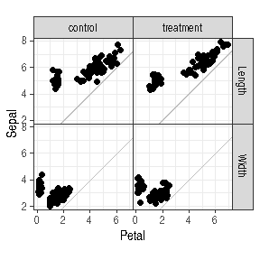

```r
## get the parts columns and groups -- is there any difference
## between groups? of course not!
parts.wide <- nc::capture_melt_multiple(
  iris.wide,
  group=".*?",
  "[.]",
  column=".*?",
  "[.]",
  dim=".*")
if(require("ggplot2")){
  ggplot()+
    theme_bw()+
    theme(panel.spacing=grid::unit(0, "lines"))+
    facet_grid(dim ~ group)+
    coord_equal()+
    geom_abline(slope=1, intercept=0, color="grey")+
    geom_point(aes(
      Petal, Sepal),
      data=parts.wide)
}
```

## Lots of column types

```r
## Example 2. Lots of column types, from example(melt.data.table).
DT <- data.table(
  i_1 = c(1:5, NA),
  i_2 = c(NA,6:10),
  f_1 = factor(sample(c(letters[1:3], NA), 6, TRUE)),
  f_2 = factor(c("z", "a", "x", "c", "x", "x"), ordered=TRUE),
  c_1 = sample(c(letters[1:3], NA), 6, TRUE),
  d_1 = as.Date(c(1:3,NA,4:5), origin="2013-09-01"),
  d_2 = as.Date(6:1, origin="2012-01-01"))
## add a couple of list cols
DT[, l_1 := DT[, list(c=list(rep(i_1, sample(5,1)))), by = i_1]$c]
DT[, l_2 := DT[, list(c=list(rep(c_1, sample(5,1)))), by = i_1]$c]

## original DT syntax is quite repetitive.
melt(DT, measure=patterns(
  i="^i",
  f="^f",
  d="^d",
  l="^l"
))
```

```
#>        c_1 variable     i      f          d              l
#>     <char>   <fctr> <int> <char>     <Date>         <list>
#>  1:      a        1     1      a 2013-09-02        1,1,1,1
#>  2:      a        1     2      a 2013-09-03            2,2
#>  3:   <NA>        1     3   <NA> 2013-09-04              3
#>  4:      b        1     4      a       <NA>          4,4,4
#>  5:      b        1     5      c 2013-09-05              5
#>  6:   <NA>        1    NA      c 2013-09-06             NA
#>  7:      a        2    NA      z 2012-01-07        a,a,a,a
#>  8:      a        2     6      a 2012-01-06      a,a,a,a,a
#>  9:   <NA>        2     7      x 2012-01-05             NA
#> 10:      b        2     8      c 2012-01-04          b,b,b
#> 11:      b        2     9      x 2012-01-03        b,b,b,b
#> 12:   <NA>        2    10      x 2012-01-02 NA,NA,NA,NA,NA
```

```r
## nc syntax uses a single regex rather than four.
nc::capture_melt_multiple(
  DT,
  column="^[^c]",
  "_",
  number="[12]")
```

```
#>        c_1 number          d      f     i              l
#>     <char> <char>     <Date> <char> <int>         <list>
#>  1:      a      1 2013-09-02      a     1        1,1,1,1
#>  2:      a      1 2013-09-03      a     2            2,2
#>  3:   <NA>      1 2013-09-04   <NA>     3              3
#>  4:      b      1       <NA>      a     4          4,4,4
#>  5:      b      1 2013-09-05      c     5              5
#>  6:   <NA>      1 2013-09-06      c    NA             NA
#>  7:      a      2 2012-01-07      z    NA        a,a,a,a
#>  8:      a      2 2012-01-06      a     6      a,a,a,a,a
#>  9:   <NA>      2 2012-01-05      x     7             NA
#> 10:      b      2 2012-01-04      c     8          b,b,b
#> 11:      b      2 2012-01-03      x     9        b,b,b,b
#> 12:   <NA>      2 2012-01-02      x    10 NA,NA,NA,NA,NA
```

```r
## id.vars can be specified using original DT syntax.
melt(DT, id=1:2, measure=patterns(
  f="^f",
  l="^l"
))
```

```
#>       i_1   i_2 variable      f              l
#>     <int> <int>   <fctr> <char>         <list>
#>  1:     1    NA        1      a        1,1,1,1
#>  2:     2     6        1      a            2,2
#>  3:     3     7        1   <NA>              3
#>  4:     4     8        1      a          4,4,4
#>  5:     5     9        1      c              5
#>  6:    NA    10        1      c             NA
#>  7:     1    NA        2      z        a,a,a,a
#>  8:     2     6        2      a      a,a,a,a,a
#>  9:     3     7        2      x             NA
#> 10:     4     8        2      c          b,b,b
#> 11:     5     9        2      x        b,b,b,b
#> 12:    NA    10        2      x NA,NA,NA,NA,NA
```

```r
nc::capture_melt_multiple(
  DT,
  column="^[fl]",
  "_",
  number="[12]")
```

```
#>       i_1   i_2    c_1        d_1        d_2 number      f              l
#>     <int> <int> <char>     <Date>     <Date> <char> <char>         <list>
#>  1:     1    NA      a 2013-09-02 2012-01-07      1      a        1,1,1,1
#>  2:     2     6      a 2013-09-03 2012-01-06      1      a            2,2
#>  3:     3     7   <NA> 2013-09-04 2012-01-05      1   <NA>              3
#>  4:     4     8      b       <NA> 2012-01-04      1      a          4,4,4
#>  5:     5     9      b 2013-09-05 2012-01-03      1      c              5
#>  6:    NA    10   <NA> 2013-09-06 2012-01-02      1      c             NA
#>  7:     1    NA      a 2013-09-02 2012-01-07      2      z        a,a,a,a
#>  8:     2     6      a 2013-09-03 2012-01-06      2      a      a,a,a,a,a
#>  9:     3     7   <NA> 2013-09-04 2012-01-05      2      x             NA
#> 10:     4     8      b       <NA> 2012-01-04      2      c          b,b,b
#> 11:     5     9      b 2013-09-05 2012-01-03      2      x        b,b,b,b
#> 12:    NA    10   <NA> 2013-09-06 2012-01-02      2      x NA,NA,NA,NA,NA
```

```r
## reshape does not support list columns.
reshape(
  DT,
  varying=grep("^[fid]", names(DT)),
  sep="_",
  direction="long",
  timevar="number")
```

```
#>        c_1     l_1            l_2 number     i     f          d    id
#>     <char>  <list>         <list>  <num> <int> <ord>     <Date> <int>
#>  1:      a 1,1,1,1        a,a,a,a      1     1     a 2013-09-02     1
#>  2:      a     2,2      a,a,a,a,a      1     2     a 2013-09-03     2
#>  3:   <NA>       3             NA      1     3  <NA> 2013-09-04     3
#>  4:      b   4,4,4          b,b,b      1     4     a       <NA>     4
#>  5:      b       5        b,b,b,b      1     5     c 2013-09-05     5
#>  6:   <NA>      NA NA,NA,NA,NA,NA      1    NA     c 2013-09-06     6
#>  7:      a 1,1,1,1        a,a,a,a      2    NA     z 2012-01-07     1
#>  8:      a     2,2      a,a,a,a,a      2     6     a 2012-01-06     2
#>  9:   <NA>       3             NA      2     7     x 2012-01-05     3
#> 10:      b   4,4,4          b,b,b      2     8     c 2012-01-04     4
#> 11:      b       5        b,b,b,b      2     9     x 2012-01-03     5
#> 12:   <NA>      NA NA,NA,NA,NA,NA      2    10     x 2012-01-02     6
```

```r
## tidyr does, but errors for combining ordered and un-ordered factors.
if(requireNamespace("tidyr")){
  tidyr::pivot_longer(
    DT, grep("[cf]", names(DT), invert=TRUE),
    names_pattern="(.)_(.)",
    names_to=c(".value", "number"))
}
```

```
#> # A tibble: 12 × 7
#>    f_1   f_2   c_1   number     i d          l
#>    <fct> <ord> <chr> <chr>  <int> <date>     <list>
#>  1 a     z     a     1          1 2013-09-02 <int [4]>
#>  2 a     z     a     2         NA 2012-01-07 <chr [4]>
#>  3 a     a     a     1          2 2013-09-03 <int [2]>
#>  4 a     a     a     2          6 2012-01-06 <chr [5]>
#>  5 <NA>  x     <NA>  1          3 2013-09-04 <int [1]>
#>  6 <NA>  x     <NA>  2          7 2012-01-05 <chr [1]>
#>  7 a     c     b     1          4 NA         <int [3]>
#>  8 a     c     b     2          8 2012-01-04 <chr [3]>
#>  9 c     x     b     1          5 2013-09-05 <int [1]>
#> 10 c     x     b     2          9 2012-01-03 <chr [4]>
#> 11 c     x     <NA>  1         NA 2013-09-06 <int [1]>
#> 12 c     x     <NA>  2         10 2012-01-02 <chr [5]>
```

## family data

```r
## Example 3, three children, one family per row, from data.table
## vignette.
family.dt <- fread(text="
family_id age_mother dob_child1 dob_child2 dob_child3 gender_child1 gender_child2 gender_child3
1         30 1998-11-26 2000-01-29         NA             1             2            NA
2         27 1996-06-22         NA         NA             2            NA            NA
3         26 2002-07-11 2004-04-05 2007-09-02             2             2             1
4         32 2004-10-10 2009-08-27 2012-07-21             1             1             1
5         29 2000-12-05 2005-02-28         NA             2             1            NA")
(children.melt <- melt(family.dt, measure = patterns(
  dob="^dob", gender="^gender"
), na.rm=TRUE, variable.factor=FALSE))
```

```
#>     family_id age_mother variable        dob gender
#>         <int>      <int>   <char>     <IDat>  <int>
#>  1:         1         30        1 1998-11-26      1
#>  2:         2         27        1 1996-06-22      2
#>  3:         3         26        1 2002-07-11      2
#>  4:         4         32        1 2004-10-10      1
#>  5:         5         29        1 2000-12-05      2
#>  6:         1         30        2 2000-01-29      2
#>  7:         3         26        2 2004-04-05      2
#>  8:         4         32        2 2009-08-27      1
#>  9:         5         29        2 2005-02-28      1
#> 10:         3         26        3 2007-09-02      1
#> 11:         4         32        3 2012-07-21      1
```

```r
## nc::field can be used to define group name and pattern at the
## same time, to avoid repetitive code.
(children.nc <- nc::capture_melt_multiple(
  family.dt,
  column="[^_]+",
  "_",
  nc::field("child", "", "[1-3]"),
  na.rm=TRUE))
```

```
#>     family_id age_mother  child        dob gender
#>         <int>      <int> <char>     <IDat>  <int>
#>  1:         1         30      1 1998-11-26      1
#>  2:         2         27      1 1996-06-22      2
#>  3:         3         26      1 2002-07-11      2
#>  4:         4         32      1 2004-10-10      1
#>  5:         5         29      1 2000-12-05      2
#>  6:         1         30      2 2000-01-29      2
#>  7:         3         26      2 2004-04-05      2
#>  8:         4         32      2 2009-08-27      1
#>  9:         5         29      2 2005-02-28      1
#> 10:         3         26      3 2007-09-02      1
#> 11:         4         32      3 2012-07-21      1
```

```r
## reshape works too.
stats::reshape(
  family.dt,
  varying=grep("child", names(family.dt)),
  direction="long",
  sep="_",
  timevar="child.str")
```

```
#>     family_id age_mother child.str        dob gender    id
#>         <int>      <int>    <char>     <IDat>  <int> <int>
#>  1:         1         30    child1 1998-11-26      1     1
#>  2:         2         27    child1 1996-06-22      2     2
#>  3:         3         26    child1 2002-07-11      2     3
#>  4:         4         32    child1 2004-10-10      1     4
#>  5:         5         29    child1 2000-12-05      2     5
#>  6:         1         30    child2 2000-01-29      2     1
#>  7:         2         27    child2       <NA>     NA     2
#>  8:         3         26    child2 2004-04-05      2     3
#>  9:         4         32    child2 2009-08-27      1     4
#> 10:         5         29    child2 2005-02-28      1     5
#> 11:         1         30    child3       <NA>     NA     1
#> 12:         2         27    child3       <NA>     NA     2
#> 13:         3         26    child3 2007-09-02      1     3
#> 14:         4         32    child3 2012-07-21      1     4
#> 15:         5         29    child3       <NA>     NA     5
```

## histogram of iris

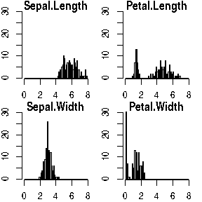

```r
## Comparison with base R. 1. mfrow means parts on rows, mfcol means
## parts on columns. 2. same number of lines of code. 3. nc/ggplot2
## code has more names and fewer numbers.
imat <- as.matrix(iris[, 1:4])
ylim <- range(table(imat))
xlim <- range(imat)
old.par <- par(mfcol=c(2,2), mar=c(2,2,1,1))
for(col.i in 1:ncol(imat)){
  hist(
    imat[, col.i],
    breaks=seq(xlim[1], xlim[2], by=0.1),
    ylim=ylim,
    main=colnames(imat)[col.i])
}
```

### single output column simple type conversion

```r
pen.peaks.wide <- data.table::data.table(
  data.set=c("foo", "bar"),
  "10.1"=c(5L, 10L),
  "0.3"=c(26L, 39L))
pen.peaks.gather <- if(requireNamespace("tidyr"))tidyr::gather(
  pen.peaks.wide,
  "penalty",
  "peaks",
  -1,
  convert=TRUE)
str(pen.peaks.gather)
```

```
#> 'data.frame':    4 obs. of  3 variables:
#>  $ data.set: chr  "foo" "bar" "foo" "bar"
#>  $ penalty : num  10.1 10.1 0.3 0.3
#>  $ peaks   : int  5 10 26 39
```

```r
pen.peaks.nc <- nc::capture_melt_single(
  pen.peaks.wide,
  penalty="^[0-9.]+", as.numeric,
  value.name="peaks")
str(pen.peaks.nc)
```

```
#> Classes 'data.table' and 'data.frame':   4 obs. of  3 variables:
#>  $ data.set: chr  "foo" "bar" "foo" "bar"
#>  $ penalty : num  10.1 10.1 0.3 0.3
#>  $ peaks   : int  5 10 26 39
#>  - attr(*, ".internal.selfref")=<externalptr>
```

```r
pen.peaks.pivot <- if(requireNamespace("tidyr"))try(tidyr::pivot_longer(
  pen.peaks.wide,
  -1,
  names_to="penalty",
  names_transform=list(penalty=as.numeric),
  values_to="peaks"))
str(pen.peaks.pivot)
```

```
#> tibble [4 × 3] (S3: tbl_df/tbl/data.frame)
#>  $ data.set: chr [1:4] "foo" "foo" "bar" "bar"
#>  $ penalty : num [1:4] 10.1 0.3 10.1 0.3
#>  $ peaks   : int [1:4] 5 26 10 39
```

```r
varying <- 2:3
pen.peaks.reshape.times <- stats::reshape(
  pen.peaks.wide,
  direction="long",
  varying=varying,
  times=as.numeric(names(pen.peaks.wide)[varying]),
  v.names="peaks",
  timevar="penalty")
str(pen.peaks.reshape.times)
```

```
#> Classes 'data.table' and 'data.frame':   4 obs. of  4 variables:
#>  $ data.set: chr  "foo" "bar" "foo" "bar"
#>  $ penalty : num  10.1 10.1 0.3 0.3
#>  $ peaks   : int  5 10 26 39
#>  $ id      : int  1 2 1 2
#>  - attr(*, ".internal.selfref")=<externalptr>
#>  - attr(*, "reshapeLong")=List of 4
#>   ..$ varying:List of 1
#>   .. ..$ peaks: chr [1:2] "10.1" "0.3"
#>   .. ..- attr(*, "v.names")= chr "peaks"
#>   .. ..- attr(*, "times")= num [1:2] 10.1 0.3
#>   ..$ v.names: chr "peaks"
#>   ..$ idvar  : chr "id"
#>   ..$ timevar: chr "penalty"
```

```r
pen.peaks.renamed <- pen.peaks.wide
names(pen.peaks.renamed) <- paste0(ifelse(
  grepl("^[0-9]", names(pen.peaks.wide)),
  "peaks_", ""),
  names(pen.peaks.wide))
pen.peaks.reshape.sep <- stats::reshape(
  pen.peaks.renamed,
  direction="long",
  varying=varying,
  sep="_",
  timevar="penalty")
str(pen.peaks.reshape.sep)
```

```
#> Classes 'data.table' and 'data.frame':   4 obs. of  4 variables:
#>  $ data.set: chr  "foo" "bar" "foo" "bar"
#>  $ penalty : num  10.1 10.1 0.3 0.3
#>  $ peaks   : int  5 10 26 39
#>  $ id      : int  1 2 1 2
#>  - attr(*, ".internal.selfref")=<externalptr>
#>  - attr(*, "reshapeLong")=List of 4
#>   ..$ varying:List of 1
#>   .. ..$ peaks: chr [1:2] "peaks_10.1" "peaks_0.3"
#>   .. ..- attr(*, "v.names")= chr "peaks"
#>   .. ..- attr(*, "times")= num [1:2] 10.1 0.3
#>   ..$ v.names: chr "peaks"
#>   ..$ idvar  : chr "id"
#>   ..$ timevar: chr "penalty"
```

### Multiple output columns of different types

```r
peaks.csv <- system.file(
  "extdata", "RD12-0002_PP16HS_5sec_GM_F_1P.csv",
  package="nc", mustWork=TRUE)
peaks.wide <- data.table::fread(peaks.csv)
tidyr.long <- tidyr::pivot_longer(
  peaks.wide,
  grep(" [0-9]", names(peaks.wide)),
  names_pattern = "(.*) ([0-9]+)",
  names_to = c(".value", "peak"),
  names_transform = list(peak=as.integer))
peaks.tall <- nc::capture_melt_multiple(
  peaks.wide,
  column=".*",
  " ",
  peak="[0-9]+", as.integer)
options(old.par)
```